# Student Performance and Predicting Their Future in Their Courses

Denitsa Goranova

## Introduction

Identifying students who may be at danger of failing a course early in their academic path is critical in educational institutions. Early intervention can result in better student results and greater possibility of success. The pursuit of better student success rates inside educational institutions has never been more vital. The aim of this notebook is to improve student achievements and well-being by providing them with predictive models. My study is more than simply facts and numbers, it is about the influence it may have on student's lives. I hope to establish a supportive, empowering educational experience. I want to predict student performance in academic courses based on previous features.

[figure not shown]

### Domain Understanding

The pursuit of better student success rates inside educational institutions has never been more vital. The aim of this project is to improve student achievements and well-being by providing them with predictive models. The project represents forecasting final grades based on previous performance. I will build a machine learning model to predict if a student is likely to pass a course. I will collect relevant data, preprocess it, choose appropriate characteristics and develop a prediction model to accomplish this. Nowadays students are facing problems in their schools and sometimes they do not even know it. I believe that by predicting a student’s academic performance and letting know those at risk of poor outcomes, I can make a difference and create a product which genuinely benefit students as well as educational institutions.

#### Research

The methods that I used are Interview and Community research. I decided to conduct an interview because it was recognized that real-world observations from students, such as the interview with Antonio Simeonov, give a detailed viewpoint. For community research- it allows me to find more complete findings, enables the investigation of communal experiences, behaviors.

## Loading libraries

Firstly, the version of the required libraries are shown.

```python
import pandas as pd
import matplotlib
import math
import matplotlib.pyplot as plt
import seaborn as sns
from sklearn.metrics import max_error
from sklearn.metrics import mean_squared_error
from sklearn.tree import DecisionTreeClassifier
from sklearn.tree import plot_tree
from sklearn.metrics import accuracy_score
from sklearn.model_selection import cross_val_score
from sklearn.model_selection import train_test_split
from sklearn.linear_model import LinearRegression
from sklearn.metrics import mean_squared_error, r2_score
from sklearn.ensemble import RandomForestRegressor
from sklearn.neighbors import KNeighborsRegressor
from sklearn.svm import SVR
from sklearn.model_selection import GridSearchCV
from sklearn.ensemble import AdaBoostRegressor
from sklearn.tree import DecisionTreeRegressor
from sklearn.preprocessing import StandardScaler
from sklearn.ensemble import VotingRegressor




print("matplotlib version:", matplotlib.__version__)    # 3.7.2
```

```
matplotlib version: 3.7.3
```

# Data Provisioning

In this section, I will delve into the fundemental aspects of data provisioning., which encompass data sourcing, transformation, integration, quality, and security. These facets are essential for ensuring data dependability, accessibility, and paving the way for effective data-driven decision-making. Data Preparation consists of four major components which are Data Requirements, Data Collection, Data Understanding and Data Preparation.

## Data requirements

To begin this journey, I require a comprehensive dataset that contains relevant information about the students, their academic performance. The dataset should include features such as age, gender, parental education, school-related variables and most cruically grades.

#### Personal information:

```
Age: Numerical data
Gender: Categorical data with categories
```

#### Parental education:

```
Parental educational levels: Categorical data with categories like 'High School', 'Bachelor's Degree', 'Master's Degree'
```

#### School- Related Variables:

```
Attendance: Numerical data representing attendance percentage
Study Time: Numerical data indicating the number of hours spent studying
Failures: Numerical data representing the number of past class failures
```

#### Grades

```
Grades: Numerical data
```

### Aditional features

```
Extracurricular activities: Categorical or numerical data indicating participation in activies such as sports, clubs

Student behavior: Categorical data assesing behavior, disciplinary incidents, engament in class
```

### Data Elements

```
Numerical Data:
    Age:
        Description: The age of the students
        Units: Years
        Range: The valid range in this case would be around 14 to 23, since typical age range of students
    Failures:
        Description: The number of past class failures by students
        Units: number of failed classes(whole number)
        Range: From 0 to the maximum number of class failures
    Attendance:
        Description: Attendance indicates number of days not being present
        Units: whole number
        Range: 0 to the maximum of days in the semester

    It includes the exused and unexused absences. Attendance data is typically collected through an automated system and teachers could be able to mark absences with specific codes. Despite that, attendance is a feature is going to be used for the final result.
    Grades:
        Description: Academic performance of students displayed in numbers
        Units: GPA
        Range: 0 to 20
Categorical Data:
    Gender:
        Categories: 'Female', 'Male'
    Parental Educational levels:
        Description: The highest education level achieved by the students' parents.
        Categories: 'High School', 'Bachelor's Degree', 'Master Degree'
```

### Data volume

In order to build an effective student grades prediction model with a target accuracy of around 90 percent, we need to gather a diverse dataset. Data volume will be a cruical factor in the project, as more extensive dataset often lead to more accurate models. I will need around 1000 results in order to achieve a good result.

### Data Quality Standards

Accuracy: Firstly in order to maintain accuracy, I am going to implement data validation checks to identify and rectify errors in the dataset. For having a proper accuracy number, I will check if the predicted grades are the same as the actual one and they are a true reflection of their academic success

Completeness: If there is some missing data, I will decide which way is going to be the best to handle it. I will develop a startegy for handling, which can be optios such as removal, imputation or other techniques. I need to have all neccesary data points in orde to have completeness.

Consistency: Establishing consistent formats for the different variables. I will a data cleaning processess so I can identify inconsitencies in the feature formats.I will also if that is neccessary, standardize units across the numerical variables, enforce conventions for the categorical data.

Relevance: It is important to select meaningful data features that directly influence academic performance. In order to get the best out of the fetaures, I will conduct exploratiry data analysis to identtify which features have a strongest correlation to academic performance.

### Ethical and Legal Aspects

In this project, it is very important to consider ethical and legal aspects. To maintain the user trust, there is not any sensible data and before anything was gathered, necessary permisions were taken. To preserve students' privacy, there was anonymized the well-being data before obtaining the raw data, such that no names or identifying numbers were included. Regardless, the collection, processing, storage, and analysis of making judgments with student data necessitates a number of ethical and legal considerations.

## Data Collection

Data collecting is an important stage in my research, which aims to improve student performance and forecast their future in educational courses. I will largely rely on educational institutions, notably secondary schools and their student records to collect the essential data. It would be good to gather relevant, recent data that aligns with the ideal data requirements. I aim to make a powerful predictive model for student grades. Up-to-date data yields more relevant insights and predictions.

### Defining Objectives

In this project, my primary objective is to investigate student future performance in secondary education with the context of two Portuguese schools. I aim to understand demographic, soical and school-related features related to student grades.

### Data Characteristics

To achieve this, I require structured data containing various attributes such as grades, demographic information and school-related features. Specifically, I need data on student performance(including G1, G2 and G3) and attributes, such as age, family relationships, parental educational levels and study time. Labeled and numerical data is essential for the nature of this project.

### Data Sources

The dataset for this project was sourced from an external database. It is a publicly available dataset, which offer valuable information to address my research questions. I am getting it from the UCI Machine Learning Repository. This is the link for the dataset that I am going to use in this porject https://archive.ics.uci.edu/dataset/320/student+performance. Unfortunately this dataset does not provide detailed insights about its origin, number of students included.However, after some analysis, I am going to be able to determine that. It is donated on 26.11.2014. While the dataset is originally from 2014, the dataset serves as a valuable resource with which I can see the fsactors affecting student performance.

#### The author of this dataset has cleared up the feature values as follows:

[output not shown]

Using pandas( powerful and easy to use open source data analysis and manipulation tool), I am reading my dataset file "student-por.csv" and storing it in a dataframe. This dataset is an eduactional database with 33 distinct variables. Several significant factors stand out in it, including parental educational levels, family interaction.

```python
# reading the dataset
# specifying that a semicolon is the delimeter between columns, decimal point in
# numeric values is ",", the data in the 1 index is going to be represented as a date
# and dayFirst is specifying the date format
data=pd.read_csv("../studentChallenge/student-por.csv",sep=';', decimal=',', parse_dates=[1], dayfirst=True)
df=pd.DataFrame(data)
```

### Data Legality and Ethics

In this instance, sensitive or private personal data about specific persons is not present in the collection; instead, it is made up of publicly accessible educational data. Terms of use, intellectual property rights, and privacy regulations are all respected while using data. I pledge to use the information responsibly, ethically, and with the utmost respect for the integrity and privacy of each individual. It is crucial to think about moral and legal implications. No private information is gathered without the required authorization. Anonymization protects the privacy of students. Some ethical factors are as follows:

```
Anonymization of data on wellbeing.
Continuous compliance with legal and moral requirements for gathering, handling, storing, and analyzing data.
Information should be used responsibly, respecting each person's privacy and integrity.
```

Although the dataset mostly consists of publicly available educational data, the addition of information about alcohol use and family dynamics calls for a cautious ethical approach. It's critical to take into account how these data may affect students' wellbeing and to make sure that reporting and analysis are done ethically. The data governance process should include ongoing ethical evaluations, with recurring reviews to meet new ethical issues and social shifts.

### Data Diversity

A comprehensive knowledge of the factors influencing student accomplishment requires a diversity of data set. I recognize how important it is to portray a range of circumstances and populations. There is some variability in the dataset as data from two different Portuguese schools is included. It's crucial to understand that the dataset could not be entirely representative of all students. During my analysis, I will take into account any potential biases and restrictions.

### Data Storage

For datasets with large size number it is good to store it in a cloud envornment, but in my case I will use local storage for now.

### Sample the data

While I primarily rely on the provided dataset for our analysis, alternative data sources for this research could be found. Educational institutions may have datasets which are related to student performance or research studies on student achievements could be a valuable source for data collection.

In order to gain an intial impression of the data and its features, a sample of 10 observations from our set is taken. The dataset consists of 649 entries.

```python
print('Students dataset shape: {}'.format(df.shape))
df.sample(10)
```

```
Students dataset shape: (649, 33)
```

|  | school | sex | age | address | famsize | Pstatus | Medu | Fedu | Mjob | Fjob | ... | famrel | freetime | goout | Dalc | Walc | health | absences | G1 | G2 | G3 |
| --- | --- | --- | --- | --- | --- | --- | --- | --- | --- | --- | --- | --- | --- | --- | --- | --- | --- | --- | --- | --- | --- |
| 572 | MS | F | 16 | U | GT3 | A | 3 | 2 | services | at_home | ... | 2 | 5 | 5 | 1 | 1 | 1 | 8 | 5 | 5 | 7 |
| 554 | MS | F | 17 | R | GT3 | T | 1 | 1 | at_home | at_home | ... | 3 | 5 | 5 | 2 | 2 | 4 | 3 | 10 | 11 | 10 |
| 358 | GP | F | 18 | U | LE3 | T | 4 | 3 | health | services | ... | 3 | 2 | 4 | 1 | 4 | 1 | 8 | 12 | 12 | 15 |
| 53 | GP | F | 15 | U | GT3 | T | 4 | 4 | services | services | ... | 3 | 3 | 4 | 2 | 3 | 5 | 0 | 13 | 12 | 12 |
| 641 | MS | F | 18 | R | GT3 | T | 2 | 2 | at_home | other | ... | 5 | 3 | 3 | 1 | 3 | 4 | 0 | 14 | 17 | 15 |
| 384 | GP | M | 19 | R | GT3 | T | 3 | 2 | at_home | services | ... | 5 | 3 | 4 | 2 | 2 | 5 | 0 | 11 | 10 | 10 |
| 569 | MS | M | 18 | U | GT3 | T | 3 | 3 | at_home | at_home | ... | 4 | 4 | 5 | 1 | 3 | 3 | 9 | 4 | 8 | 8 |
| 111 | GP | F | 16 | R | GT3 | T | 3 | 3 | services | other | ... | 4 | 1 | 2 | 1 | 1 | 2 | 4 | 11 | 11 | 11 |
| 295 | GP | M | 19 | U | LE3 | A | 4 | 3 | services | at_home | ... | 4 | 3 | 1 | 1 | 1 | 1 | 4 | 11 | 13 | 14 |
| 579 | MS | M | 18 | U | LE3 | T | 1 | 3 | at_home | services | ... | 4 | 3 | 3 | 2 | 3 | 3 | 0 | 9 | 10 | 9 |

10 rows × 33 columns

### Quick look at the data

I use the .info() method to produce a summary of statistics for the dataframe columns to gain a better knowledge of the dataset.

```python
df.info()
```

```
<class 'pandas.core.frame.DataFrame'>
RangeIndex: 649 entries, 0 to 648
Data columns (total 33 columns):
 #   Column      Non-Null Count  Dtype
---  ------      --------------  -----
 0   school      649 non-null    object
 1   sex         649 non-null    object
 2   age         649 non-null    int64
 3   address     649 non-null    object
 4   famsize     649 non-null    object
 5   Pstatus     649 non-null    object
 6   Medu        649 non-null    int64
 7   Fedu        649 non-null    int64
 8   Mjob        649 non-null    object
 9   Fjob        649 non-null    object
```

[output cut: 25 more lines]

## Data Preparation

For purposes of our analysis and more specifically when working with categorical data on machine learning, one-hot encoding is a critical data preparation step. It is required because achine learning models, particularly those implemented in libraries such as scikit-learn, require numerical input data/ One-hot encoding is used to convert categorical information into a binary matrix, where each category is represented by a distinct binary column with 0s and 1s. Because it avoids the requirement to intrepret the original categories as numerical values, which may lead to undesired ordinal associations, the translation assures that the machine learning algorithm can funtion successfully with the data.

```python
# Using pandas' get_dummies to perform one-hot encoding
df = pd.get_dummies(df, columns=['schoolsup','guardian','activities', 'Pstatus', 'famsup', 'paid', 'famsize', 'sex', 'address', 'school'])
df.columns
```

```
Index(['age', 'Medu', 'Fedu', 'Mjob', 'Fjob', 'reason', 'traveltime',
       'studytime', 'failures', 'nursery', 'higher', 'internet', 'romantic',
       'famrel', 'freetime', 'goout', 'Dalc', 'Walc', 'health', 'absences',
       'G1', 'G2', 'G3', 'schoolsup_no', 'schoolsup_yes', 'guardian_father',
       'guardian_mother', 'guardian_other', 'activities_no', 'activities_yes',
       'Pstatus_A', 'Pstatus_T', 'famsup_no', 'famsup_yes', 'paid_no',
       'paid_yes', 'famsize_GT3', 'famsize_LE3', 'sex_F', 'sex_M', 'address_R',
       'address_U', 'school_GP', 'school_MS'],
      dtype='object')
```

## Data Understanding

In this part, we investigate the dataset to learn more about its properties and interelationsips. To bgin, we use the ".describe()" method to obtain summary of statistics pertaining the dataFrame columns.

```python
df.describe()
```

|  | age | Medu | Fedu | traveltime | studytime | failures | famrel | freetime | goout | Dalc | Walc | health | absences | G1 | G2 | G3 |
| --- | --- | --- | --- | --- | --- | --- | --- | --- | --- | --- | --- | --- | --- | --- | --- | --- |
| count | 649.000000 | 649.000000 | 649.000000 | 649.000000 | 649.000000 | 649.000000 | 649.000000 | 649.000000 | 649.000000 | 649.000000 | 649.000000 | 649.000000 | 649.000000 | 649.000000 | 649.000000 | 649.000000 |
| mean | 16.744222 | 2.514638 | 2.306626 | 1.568567 | 1.930663 | 0.221880 | 3.930663 | 3.180277 | 3.184900 | 1.502311 | 2.280431 | 3.536210 | 3.659476 | 11.399076 | 11.570108 | 11.906009 |
| std | 1.218138 | 1.134552 | 1.099931 | 0.748660 | 0.829510 | 0.593235 | 0.955717 | 1.051093 | 1.175766 | 0.924834 | 1.284380 | 1.446259 | 4.640759 | 2.745265 | 2.913639 | 3.230656 |
| min | 15.000000 | 0.000000 | 0.000000 | 1.000000 | 1.000000 | 0.000000 | 1.000000 | 1.000000 | 1.000000 | 1.000000 | 1.000000 | 1.000000 | 0.000000 | 0.000000 | 0.000000 | 0.000000 |
| 25% | 16.000000 | 2.000000 | 1.000000 | 1.000000 | 1.000000 | 0.000000 | 4.000000 | 3.000000 | 2.000000 | 1.000000 | 1.000000 | 2.000000 | 0.000000 | 10.000000 | 10.000000 | 10.000000 |
| 50% | 17.000000 | 2.000000 | 2.000000 | 1.000000 | 2.000000 | 0.000000 | 4.000000 | 3.000000 | 3.000000 | 1.000000 | 2.000000 | 4.000000 | 2.000000 | 11.000000 | 11.000000 | 12.000000 |
| 75% | 18.000000 | 4.000000 | 3.000000 | 2.000000 | 2.000000 | 0.000000 | 5.000000 | 4.000000 | 4.000000 | 2.000000 | 3.000000 | 5.000000 | 6.000000 | 13.000000 | 13.000000 | 14.000000 |
| max | 22.000000 | 4.000000 | 4.000000 | 4.000000 | 4.000000 | 3.000000 | 5.000000 | 5.000000 | 5.000000 | 5.000000 | 5.000000 | 5.000000 | 32.000000 | 19.000000 | 19.000000 | 19.000000 |

For age distribution, I can say that most students fall within the 16 to 18-year age group, for parental education-on average, parents have received a moderate level of education.

### Checking for duplications

We investigate the dataset for duplicate rows using the ".duplicated()" function and present any duplicated rows if they exist.

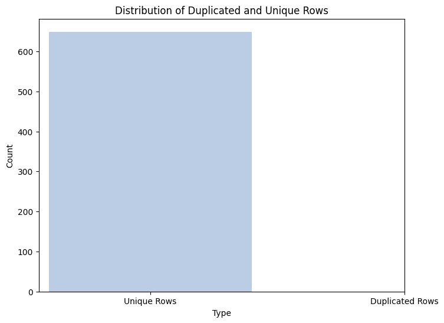

```python
duplicated_rows = df.duplicated(subset=df.columns)
duplicated_counts = duplicated_rows.value_counts()

plt.figure(figsize=(8, 6))
plt.bar(duplicated_counts.index, duplicated_counts.values, color=['#bbcde5', 'black'])
plt.xticks([0, 1], ['Unique Rows', 'Duplicated Rows'])
plt.xlabel('Type')
plt.ylabel('Count')
plt.title('Distribution of Duplicated and Unique Rows')
plt.show()
```

Based on the diagram, I can conclude that there aren't any visible duplicated rows.

### Check for missing values

When we want to check if there are any null values we use the command "isna()". As a result we see, that our our dataset does not have any.

```python
df.isna().sum()
```

```
age                0
Medu               0
Fedu               0
Mjob               0
Fjob               0
reason             0
traveltime         0
studytime          0
failures           0
nursery            0
higher             0
internet           0
romantic           0
famrel             0
freetime           0
goout              0
Dalc               0
Walc               0
health             0
absences           0
G1                 0
G2                 0
G3                 0
schoolsup_no       0
schoolsup_yes      0
guardian_father    0
guardian_mother    0
guardian_other     0
activities_no      0
activities_yes     0
Pstatus_A          0
Pstatus_T          0
famsup_no          0
famsup_yes         0
paid_no            0
paid_yes           0
famsize_GT3        0
famsize_LE3        0
sex_F              0
sex_M              0
address_R          0
address_U          0
school_GP          0
school_MS          0
dtype: int64
```

A histogram depicting the distribution of student ages provides valuable insights into age demographics within the dataset.

Creating a plot that visualizes the distribution of grades G1 by school with different colors representing the school. As we can see the grades vary between 0 and 20.

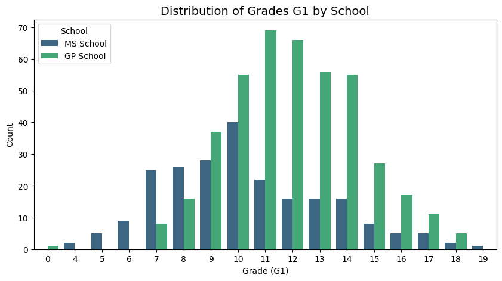

```python
# Create a figure with size 10, 5
plt.figure(figsize=(10, 5))

# Create a countplot using the one-hot encoded school columns
ax = sns.countplot(data=df, x="G1", hue="school_GP", palette="viridis")

# Define custom legend labels
legend_labels = ['MS School', 'GP School']

# Place a legend with custom labels for the schools
ax.legend(loc='upper left', labels=legend_labels, title="School")

# Set the labels, title, and show the plot
plt.title('Distribution of Grades G1 by School', fontsize=14)
ax.set(xlabel='Grade (G1)', ylabel='Count')
plt.show()
```

What I can observe from the plot is that MS School appear to have a larger concentration of students with lower grades, while GP School appears to have a more evenly spread distribution of grades accross the various perfromance levels. The differences between the grade distributions suggest that school could be an important feature to consider in predictive models.

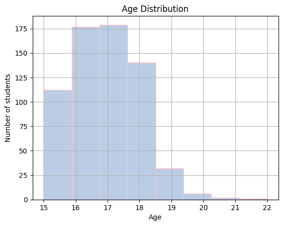

```python
df['age'].hist(bins=8,color='#bbcde5',edgecolor='pink')
plt.title("Age Distribution")
plt.xlabel('Age')
plt.ylabel('Number of students')
plt.show()
```

```python
age_counts = df['age'].value_counts().sort_index()
print(age_counts)
```

```
age
15    112
16    177
17    179
18    140
19     32
20      6
21      2
22      1
Name: count, dtype: int64
```

Based on the histogram, I can say that the majority of students fall within the age range of 15 to 18. Portuguese secondary schools often have students whoose age is from 15 -18, so I can assume that the students with age 19,20,21,22 is based on failures, absences, late start of school or some other reason.

A bar plot illustrating the distribution of students across different schools, Gabriel Pereira (GP) and Mousinho de Silveira (MS), provides insights into the school distribution.

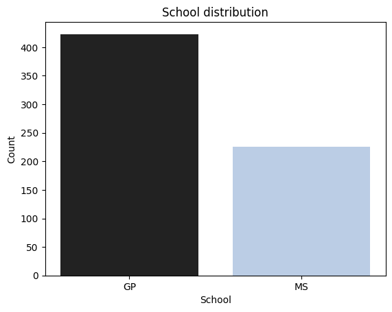

```python
school_counts = df['school_MS'].value_counts()
schools = ["GP", "MS"]

plt.bar(school_counts.index, school_counts.values, color=['#222222', '#bbcde5'])
plt.xlabel("School")
plt.ylabel("Count")
plt.title("School distribution")

# setting the labels in the plot
plt.xticks(school_counts.index, schools)
plt.show()
```

The barplot reveleas interesting insights. We have two schools GP School and MS School. From the plot, I can observe that GP School has a significantly larger number of students. It is important to know that GP school students dominate the dataset.

I am now going to calculate the mean grade of every student which is going to help us for analysis and decision making.

```python
# calculating the mean grade of students
grad_mean=(df.G1+df.G2+df.G3)/3
#adding a new column with the mean grade value
df['G_Mean']=grad_mean
df.head()
```

|  | age | Medu | Fedu | Mjob | Fjob | reason | traveltime | studytime | failures | nursery | ... | paid_yes | famsize_GT3 | famsize_LE3 | sex_F | sex_M | address_R | address_U | school_GP | school_MS | G_Mean |
| --- | --- | --- | --- | --- | --- | --- | --- | --- | --- | --- | --- | --- | --- | --- | --- | --- | --- | --- | --- | --- | --- |
| 0 | 18 | 4 | 4 | at_home | teacher | course | 2 | 2 | 0 | yes | ... | False | True | False | True | False | False | True | True | False | 7.333333 |
| 1 | 17 | 1 | 1 | at_home | other | course | 1 | 2 | 0 | no | ... | False | True | False | True | False | False | True | True | False | 10.333333 |
| 2 | 15 | 1 | 1 | at_home | other | other | 1 | 2 | 0 | yes | ... | False | False | True | True | False | False | True | True | False | 12.333333 |
| 3 | 15 | 4 | 2 | health | services | home | 1 | 3 | 0 | yes | ... | False | True | False | True | False | False | True | True | False | 14.000000 |
| 4 | 16 | 3 | 3 | other | other | home | 1 | 2 | 0 | yes | ... | False | True | False | True | False | False | True | True | False | 12.333333 |

5 rows × 45 columns

The addition of the 'G_Mean' column improves our dataset and provides a more thorough depiction of each student's academic performance, allowing for more accurate projections of future grades and overall project goals.

I am now creating a pie chart to visualize the gender distribution. In that type of project it is good to know what the majority of students is.

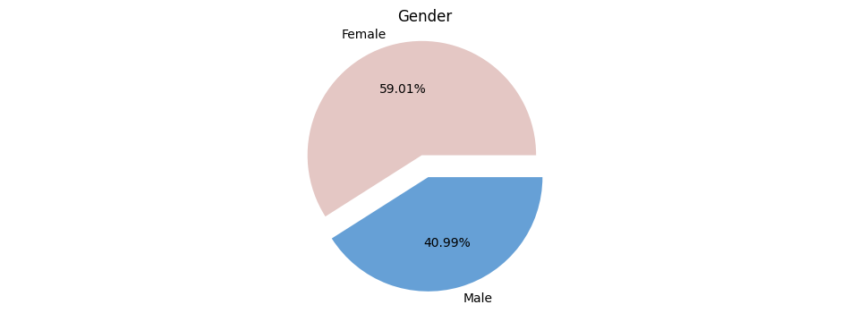

```python
##Created a new plot with size specifics
plt.figure(figsize=(12,4))

#defined the labels
labels=['Female','Male']

#Created a pie chart with the ["sex"] column from my dataFrame and specified its color, seperated the
#different results and showed the percentage
plt.pie(df['sex_M'].value_counts(),labels=labels,autopct='%1.2f%%',explode=[0.1,0.1], colors=['#e4c7c4','#66a0d6'])

plt.title("Gender")
plt.axis("equal"); ##ensuring the chart is circular
```

Having a dataset with around 60% female students and around 40% male student is quite common in many real-world scenarios. Understanding and acknowledging the gender distribution in the dataset is a crucial step in the data analysis process, leading to more informed and balanced insights into student performance and acedemic outcomes.

I decided firstly to see if study hours have impact on student performance, since first thing that comes up in my mind is that. Student performance by study hours by barplot shows that the longer hours you study, the greater results you receive.

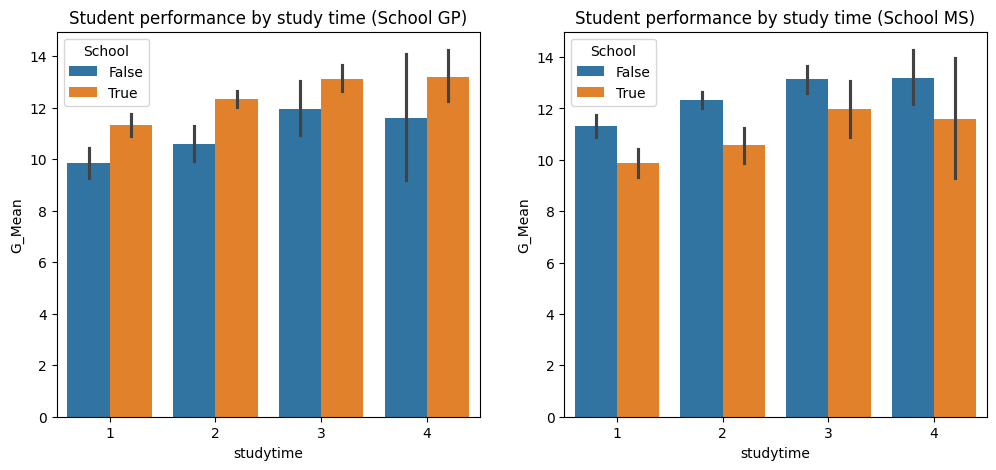

```python
fig, axes = plt.subplots(1, 2, figsize=(12, 5))

sns.barplot(x="studytime", y="G_Mean", hue="school_GP", data=df, ax=axes[0])
axes[0].set_title("Student performance by study time (School GP)")
axes[0].legend(loc='upper left', title="School")

sns.barplot(x="studytime", y="G_Mean", hue="school_MS", data=df, ax=axes[1])
axes[1].set_title("Student performance by study time (School MS)")
axes[1].legend(loc='upper left', title="School")
```

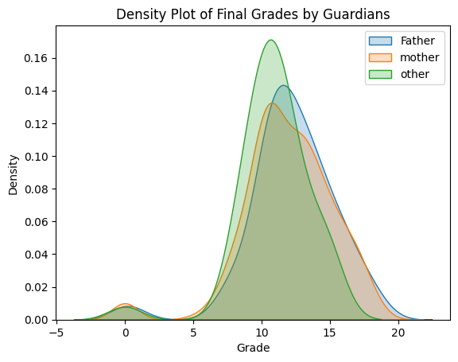

```python
# Create a density plot for students with differnt guardians
sns.kdeplot(df[df['guardian_father']]['G3'], label='Father', shade=True)

sns.kdeplot(df[df['guardian_mother']]['G3'], label='mother', shade=True)

sns.kdeplot(df[df['guardian_other']]['G3'], label='other', shade=True)

plt.xlabel('Grade')
plt.ylabel('Density')
plt.title('Density Plot of Final Grades by Guardians')

plt.legend();
```

Based on the plot, there is not any huge differenece between having a mother and father guardian, although "other" have higher density in grades around 10.

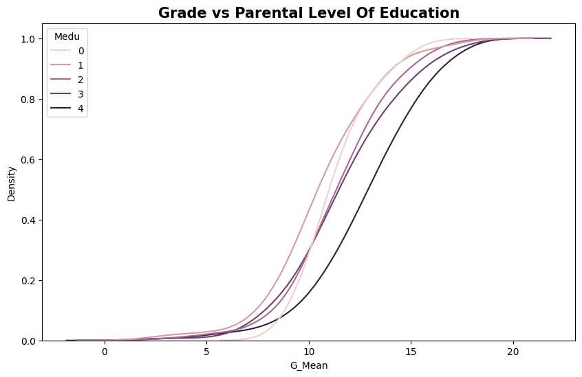

```python
plt.figure(figsize=(10, 6))
sns.kdeplot(data=df, x="G_Mean", hue="Medu", cumulative=True, common_norm=False)

plt.title('Grade vs Parental Level Of Education', fontsize=15, fontweight='bold')

plt.show()
```

Something that I find interesting is that students whoose parents does not have any education does not have grades lower than 6. Another thing I can conclude from the graph is that density of students whoose parent with higher education tend to have a smaller amount of grades in the middle.

By comparing these plots, I may acquire insights into how student performance changes over time and better comprehend the distribution of final test results ('G3') in comparison to previous grading periods.

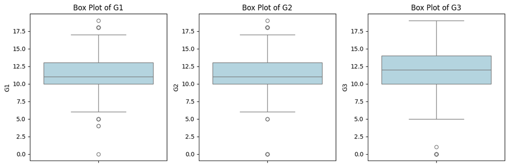

```python
plt.figure(figsize=(12, 4))

# Plot box plots for 'G1', 'G2', and 'G3'
for i, feature in enumerate(['G1', 'G2', 'G3']):
    plt.subplot(1, 3, i+1)
    sns.boxplot(y=df[feature], color='lightblue')
    plt.title(f'Box Plot of {feature}')
    plt.ylabel(feature)

plt.tight_layout()
plt.show()
```

As we can see, G1(slightly right-skewed distribution) box shows a median of around 11, and there were some students that scored relatively low grades. For G2 box the median is arounf 11 again and there are some outliers as well. For G3 ther is a higher median and has fewer outliers on the low part. Overall G1 and G2 have similar distribution, but there ws more variability in G3.

[figure not shown]

```python
fig, axes = plt.subplots(nrows=3, ncols=1, figsize=(10, 12))

sns.countplot(ax=axes[0], x='traveltime', data=df, palette='viridis')
axes[0].set_title('Distribution of Traveltime')

sns.countplot(ax=axes[1], x='studytime', data=df, palette='viridis')
axes[1].set_title('Distribution of Studytime')

sns.countplot(ax=axes[2], x='failures', data=df, palette='viridis')
axes[2].set_title('Distribution of Failures')

plt.tight_layout()
plt.show()
```

Something else that I believe have impact on student performance are study time, failures and travel time. I decided that I am going to show where the majority stands and check if there is a correlation between those features and the grades.

[output not shown]

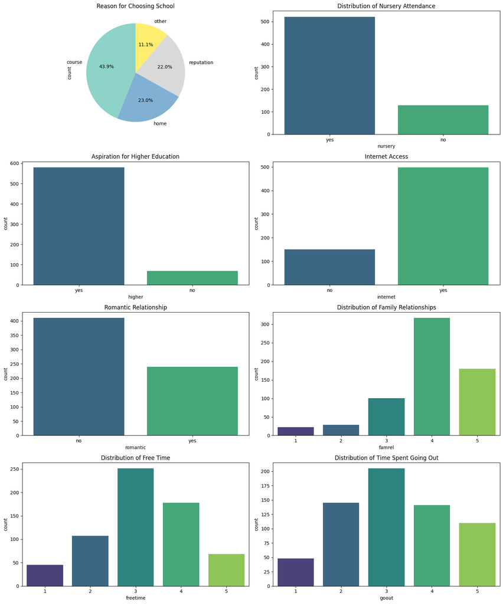

```python
fig, axes = plt.subplots(nrows=4, ncols=2, figsize=(15, 18))

df['reason'].value_counts().plot.pie(ax=axes[0, 0], autopct='%1.1f%%', startangle=90, cmap='Set3')
axes[0, 0].set_title('Reason for Choosing School')

sns.countplot(ax=axes[0, 1], x='nursery', data=df, palette='viridis')
axes[0, 1].set_title('Distribution of Nursery Attendance')

sns.countplot(ax=axes[1, 0], x='higher', data=df, palette='viridis')
axes[1, 0].set_title('Aspiration for Higher Education')

sns.countplot(ax=axes[1, 1], x='internet', data=df, palette='viridis')
axes[1, 1].set_title('Internet Access')

sns.countplot(ax=axes[2, 0], x='romantic', data=df, palette='viridis')
axes[2, 0].set_title('Romantic Relationship')

sns.countplot(ax=axes[2, 1], x='famrel', data=df, palette='viridis')
axes[2, 1].set_title('Distribution of Family Relationships')

sns.countplot(ax=axes[3, 0], x='freetime', data=df, palette='viridis')
axes[3, 0].set_title('Distribution of Free Time')

sns.countplot(ax=axes[3, 1], x='goout', data=df, palette='viridis')
axes[3, 1].set_title('Distribution of Time Spent Going Out')

plt.tight_layout()
plt.show()
```

[output not shown]

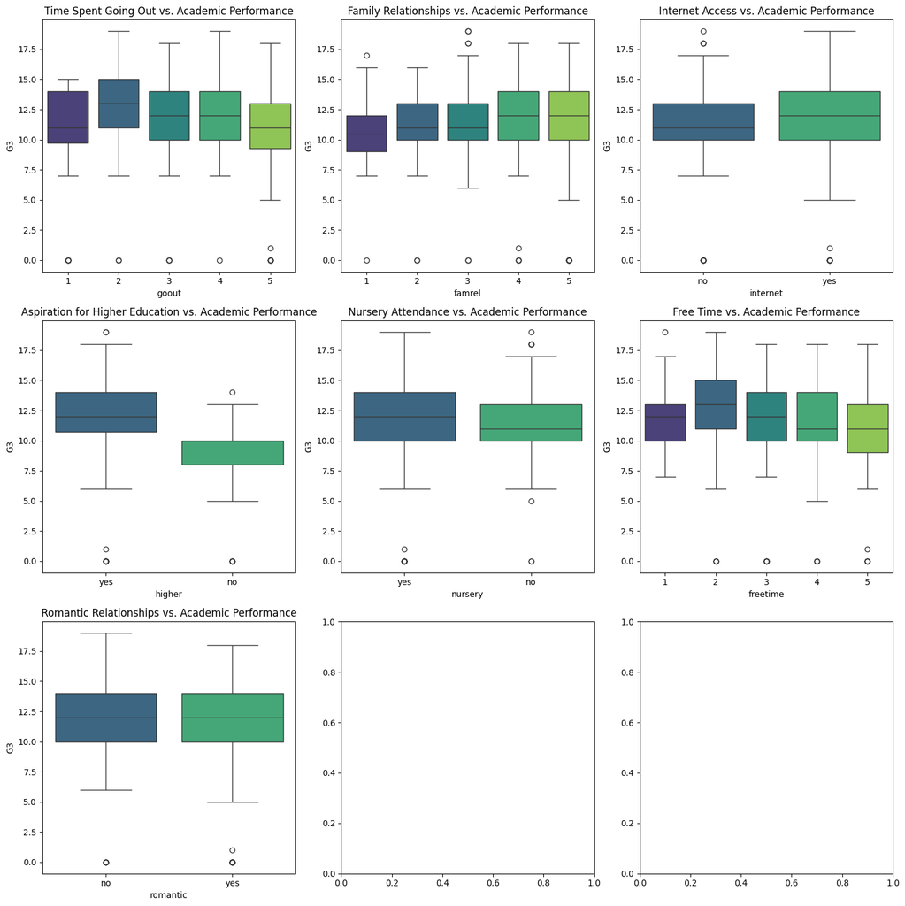

```python
fig, axes = plt.subplots(nrows=3, ncols=3, figsize=(15, 15))

sns.boxplot(ax=axes[0, 0], x='goout', y='G3', data=df, palette='viridis')
axes[0, 0].set_title('Time Spent Going Out vs. Academic Performance')

sns.boxplot(ax=axes[0, 1], x='famrel', y='G3', data=df, palette='viridis')
axes[0, 1].set_title('Family Relationships vs. Academic Performance')

sns.boxplot(ax=axes[0, 2], x='internet', y='G3', data=df, palette='viridis')
axes[0, 2].set_title('Internet Access vs. Academic Performance')

sns.boxplot(ax=axes[1, 0], x='higher', y='G3', data=df, palette='viridis')
axes[1, 0].set_title('Aspiration for Higher Education vs. Academic Performance')

sns.boxplot(ax=axes[1, 1], x='nursery', y='G3', data=df, palette='viridis')
axes[1, 1].set_title('Nursery Attendance vs. Academic Performance')

sns.boxplot(ax=axes[1, 2], x='freetime', y='G3', data=df, palette='viridis')
axes[1, 2].set_title('Free Time vs. Academic Performance')

sns.boxplot(ax=axes[2, 0], x='romantic', y='G3', data=df, palette='viridis')
axes[2, 0].set_title('Romantic Relationships vs. Academic Performance')


plt.tight_layout()
plt.show()
```

[output not shown]

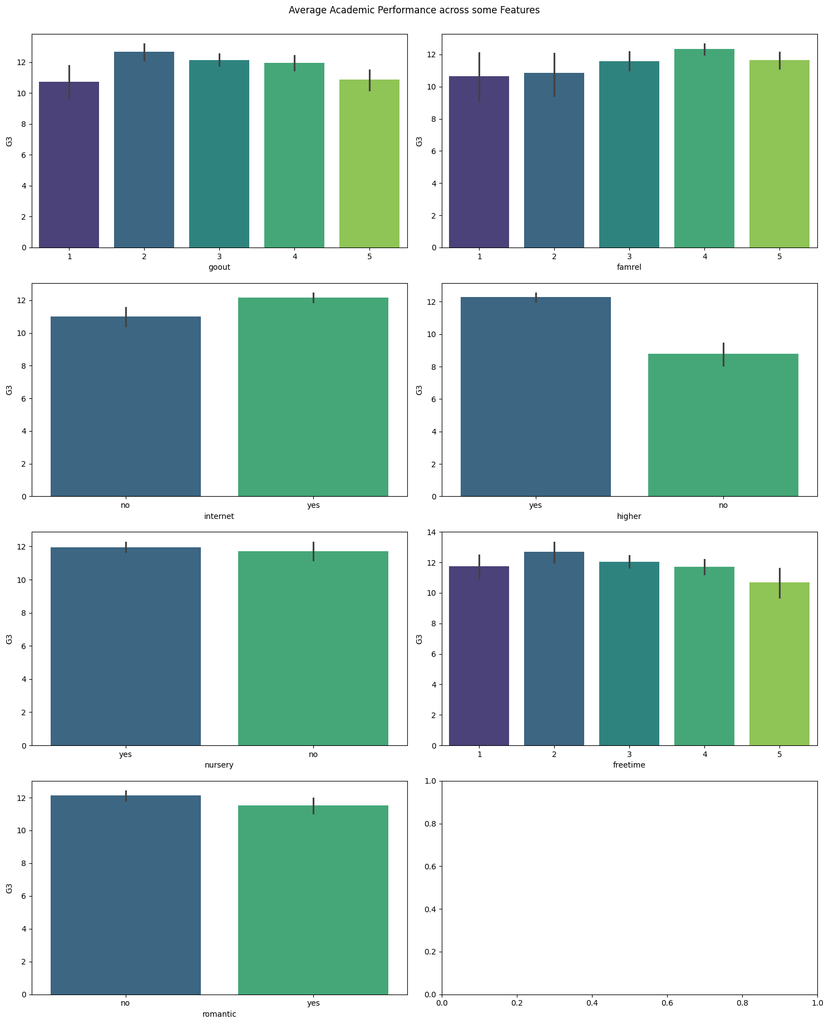

```python
selected_columns = ['G3', 'goout', 'famrel', 'internet', 'higher', 'nursery', 'freetime', 'romantic']

fig, axes = plt.subplots(nrows=4, ncols=2, figsize=(15, 18))

for i, column in enumerate(selected_columns[1:]):
    sns.barplot(ax=axes[i // 2, i % 2], x=column, y='G3', data=df, palette='viridis')

plt.tight_layout()
plt.suptitle('Average Academic Performance across some Features', y=1.02)
```

## Predictions

### Preprocessing

The step of preprocessing contains several activities to consider before we can start training our algorithm.

### Feature selection

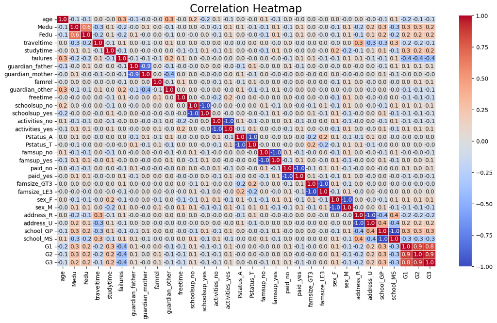

```python
# Selecting the relevant columns, including one-hot encoded features
selected_columns = df[[
    'age', 'Medu', 'Fedu', 'traveltime', 'studytime', 'failures','guardian_father','guardian_mother',
      'famrel','guardian_other',
    'freetime', 'schoolsup_no', 'schoolsup_yes', 'activities_no', 'activities_yes',
    'Pstatus_A', 'Pstatus_T', 'famsup_no', 'famsup_yes', 'paid_no', 'paid_yes',
    'famsize_GT3', 'famsize_LE3', 'sex_F', 'sex_M', 'address_R', 'address_U',
    'school_GP', 'school_MS', 'G1', 'G2', 'G3'
]]

# Calculate the correlation matrix
correlation_matrix = selected_columns.corr()

# Create a figure with a size that accommodates the heatmap
plt.figure(figsize=(15, 8))

# Create the heatmap
sns.heatmap(correlation_matrix, annot=True, cmap='coolwarm', linewidths=.5, fmt=".1f")

# Set the title for the heatmap
plt.title('Correlation Heatmap', fontsize=19)

# Show the heatmap
plt.show()
```

Based on the correlation map and domain knowledge, I choose the following features: Medu and Fedu- educational levels of parents can have impact on student's academic success age- different needs and learning abilities can be a reason for various academic performance points absences- could be a strong predictor for grades failures- may be used as an indicator of studen's performance studytime- could be a determinant of student's performance as well

```python
features= [
    'age', 'Medu', 'Fedu', 'traveltime', 'studytime', 'failures', 'famrel',
    'freetime', 'goout', 'Dalc', 'Walc', 'health', 'absences','school_GP', 'school_MS',
]
target="G3"
X=df[features]
y=df[target]
```

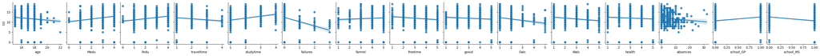

```python
plot = sns.pairplot(df, x_vars=features, y_vars=target, kind="reg")
```

### Splitting into train/test data

We split our data into a training set and a testing set to facilitate model training and evaluation.

Before our model train, we are going to put aside some part of our data for testing purpose. The train set is used to train the model and the test set is going to help me evaluate the performance.

```python
X_train, X_test, y_train, y_test = train_test_split(X, y, test_size=.2, random_state=1)
print("There are in total" ,len(X), "observations,",len(X_train), "are now in the train set",len(X_test),"in test set")
```

```
There are in total 649 observations, 519 are now in the train set 130 in test set
```

### Modelling- Predicitive Analytics

```python
import joblib

continuous_features = ['G1', 'G2', 'Medu', 'Fedu', 'failures', 'studytime']

features = continuous_features + ['sex_F'] + ['sex_M']

X = df[features]
y = df['G3']

X_train, X_test, y_train, y_test = train_test_split(X, y, test_size=0.2, random_state=42)

# Create a StandardScaler instance to normalize the data
scaler = StandardScaler()

X_train[continuous_features] = scaler.fit_transform(X_train[continuous_features])
X_test[continuous_features] = scaler.transform(X_test[continuous_features])
joblib.dump(scaler, 'your_scaler.pkl')
```

```
['your_scaler.pkl']
```

### Linear Regression

```python
# Create and fit the linear regression model
model = LinearRegression()
model.fit(X_train, y_train)

# Make predictions
y_pred = model.predict(X_test)
y_pred_int = y_pred.round().astype(int)

# Calculate and print evaluation metrics for the model
mse = mean_squared_error(y_test, y_pred)
r2 = r2_score(y_test, y_pred)

print(F"Mean Squared Error (MSE): {mse:.2f}")
print(f"R-squared (Accuracy): {r2}")

mse_int = mean_squared_error(y_test, y_pred_int)
r2_int = r2_score(y_test, y_pred_int)

print(F"Mean Squared Error with integer values: {mse_int:.2f}")
print(f"R-squared (Accuracy) with integer values: {r2_int}")
```

```
Mean Squared Error (MSE): 1.34
R-squared (Accuracy): 0.862925888707601
Mean Squared Error with integer values: 1.48
R-squared (Accuracy) with integer values: 0.8477585495497681
```

### Random Forest

Random Forest is selected as well for its ability to give a reliable, high-performing predictive modeling solution, ease of use and insightful feature significance analysis. Based on the results, I am going see if it is a match for this project problem.

```python
X_train, X_test, y_train, y_test = train_test_split(X, y, test_size=0.2, random_state=42)

rf_model = RandomForestRegressor(n_estimators=100, random_state=42)

rf_model.fit(X_train, y_train)

y_pred = rf_model.predict(X_test)

mse_randomForest = mean_squared_error(y_test, y_pred)
r2_randomForest = r2_score(y_test, y_pred)

print(F"Mean Squared Error (MSE): {mse_randomForest:.2f}")
print(f"R-squared (Accuracy): {r2_randomForest:.2f}")
```

```
Mean Squared Error (MSE): 2.21
R-squared (Accuracy): 0.77
```

### Support Vector Regression

SVR is less sensitive to outlies, but SVR is an advantage for smaller datasets.

```python
# Split the data into a training set and a testing set
X_train, X_test, y_train, y_test = train_test_split(X, y, test_size=0.2, random_state=42)

# Create a Support Vector Machine Regressor model
svm_model = SVR(kernel='linear')

# Fit the model to the training data
svm_model.fit(X_train, y_train)

# Make predictions on the test data
y_pred = svm_model.predict(X_test)

# Calculate and print evaluation metrics
mse_svm = mean_squared_error(y_test, y_pred)
r2_svm = r2_score(y_test, y_pred)

print(F"Mean Squared Error (MSE): {mse_svm:.2f}")
print(f"R-squared (Accuracy): {r2_svm:.2f}")
```

```
Mean Squared Error (MSE): 1.29
R-squared (Accuracy): 0.87
```

### Linear regression+ SVR+ Random Forest

```python
# Train the Linear Regression model
linear_reg = LinearRegression()
linear_reg.fit(X_train, y_train)

# Train the Random Forest model
random_forest = RandomForestRegressor(n_estimators=180, random_state=42)
random_forest.fit(X_train, y_train)

# Train the SVR model
svr = SVR(kernel='linear',C= 20, epsilon= 1,)
svr.fit(X_train, y_train)

# Make predictions
linear_reg_preds = linear_reg.predict(X_test)
random_forest_preds = random_forest.predict(X_test)
svr_preds = svr.predict(X_test)

# Combine predictions
ensemble_preds = (linear_reg_preds + random_forest_preds + svr_preds) / 3

# Evaluate the ensemble
r2_ensemble = r2_score(y_test, ensemble_preds)
mse_ensemble = mean_squared_error(y_test, y_pred)

print(f"Ensemble R-squared: {r2_ensemble:.2f}")
```

```
Ensemble R-squared: 0.85
```

### Hyperparameter tunning

```python
# Hyperparameter tuning for Linear Regression
linear_reg = LinearRegression()
param_grid_linear = {
    'fit_intercept': [True, False],
    'positive': [True, False],
    'copy_X': [True, False]
}
grid_search_linear = GridSearchCV(linear_reg, param_grid_linear, cv=5, scoring='r2')
grid_search_linear.fit(X_train, y_train)
best_linear_reg = grid_search_linear.best_estimator_

# Hyperparameter tuning for Random Forest
random_forest = RandomForestRegressor(n_estimators=180, random_state=42)
param_grid_rf = {
    'n_estimators': [100, 200, 300],
    'max_depth': [None, 10, 20, 30],
}
grid_search_rf = GridSearchCV(random_forest, param_grid_rf, cv=5, scoring='r2')
grid_search_rf.fit(X_train, y_train)
best_random_forest = grid_search_rf.best_estimator_

# Hyperparameter tuning for SVR
svr = SVR(kernel='linear', C=20, epsilon=1)
param_grid_svr = {
    'C': [1, 10, 20, 50],
    'epsilon': [0.1, 1, 10],
}
grid_search_svr = GridSearchCV(svr, param_grid_svr, cv=5, scoring='r2')
grid_search_svr.fit(X_train, y_train)
best_svr = grid_search_svr.best_estimator_
print(best_svr)
print(best_random_forest)
print(best_linear_reg)
```

```
SVR(C=10, epsilon=1, kernel='linear')
RandomForestRegressor(max_depth=10, n_estimators=300, random_state=42)
LinearRegression(fit_intercept=False, positive=True)
```

### Cross-validation

```python
ensemble = VotingRegressor(estimators=[
    ('linear_reg', best_linear_reg),
    ('random_forest', best_random_forest),
    ('svr', best_svr)
])

cross_val_scores = cross_val_score(ensemble, X_train, y_train, cv=5, scoring='r2')

print("Cross-Validation:")
for i, score in enumerate(cross_val_scores):
    print(f"Fold {i + 1}: {score:.2f}")

mean_r2_score = cross_val_scores.mean()
print(f"Mean Cross-Validation R-squared: {mean_r2_score:.2f}")
```

```
Cross-Validation:
Fold 1: 0.88
Fold 2: 0.75
Fold 3: 0.86
Fold 4: 0.88
Fold 5: 0.88
Mean Cross-Validation R-squared: 0.85
```

Based on the results, it appears that the model is performing quite well, on average I have 85% in the target variable. There isn't a huge difference between the differencec fold which indicates no overfitting.

### KNeighbor Regressor

```python
# Split the data into a training set and a testing set
X_train, X_test, y_train, y_test = train_test_split(X, y, test_size=0.2, random_state=42)

# Create a KNN Regressor model with k=5 (you can adjust k as needed)
knn_model = KNeighborsRegressor(n_neighbors=5)

# Fit the model to the training data
knn_model.fit(X_train, y_train)

# Make predictions on the test data
y_pred = knn_model.predict(X_test)

# Calculate and print evaluation metrics
mse_knn = mean_squared_error(y_test, y_pred)
r2_knn = r2_score(y_test, y_pred)

print(F"Mean Squared Error (MSE): {mse_knn:.2f}")
print(f"R-squared (Accuracy): {r2_knn:.2f}")
```

```
Mean Squared Error (MSE): 1.95
R-squared (Accuracy): 0.80
```

```python
model_names = []
mse_values = []
accuracy_values = []
mse_ensemble = mean_squared_error(y_test, ensemble_preds)


def add_result(model_name, mse, accuracy):
    model_names.append(model_name)
    mse_values.append(mse)
    accuracy_values.append(accuracy)

add_result("KNN Regressor", mse_knn, r2_knn)
add_result("SVR Regressor", mse_svm, r2_svm)
add_result("Random Forest Regressor", mse_randomForest, r2_randomForest)
add_result("Linear Regression", mse, r2_int)
add_result("Ensemble (Linear + RF + SVR)", mse_ensemble, r2_ensemble)

results_df = pd.DataFrame({
    "Model": model_names,
    "Mean Squared Error (MSE)": mse_values,
    "R-squared-Accuracy": accuracy_values
})

results_df
```

|  | Model | Mean Squared Error (MSE) | R-squared-Accuracy |
| --- | --- | --- | --- |
| 0 | KNN Regressor | 1.952923 | 0.799735 |
| 1 | SVR Regressor | 1.288398 | 0.867880 |
| 2 | Random Forest Regressor | 2.205591 | 0.773825 |
| 3 | Linear Regression | 1.336708 | 0.847759 |
| 4 | Ensemble (Linear + RF + SVR) | 1.460038 | 0.850279 |

Evaluating differernt models in order to compare their performance will help us get a sight of which methods perform better than other.

```python
# Define the models
models = {
    'Linear Regression': LinearRegression(),
    'Random Forest': RandomForestRegressor(n_estimators=180, random_state=82),
    'SVR': SVR(kernel='linear'),
    'KNeighbors': KNeighborsRegressor(),

}

results = {'Model': [], 'Test MSE': [], 'Test R-squared': [], 'Train MSE': []}

# Train the models and evaluate
for model_name, model in models.items():
    model.fit(X_train, y_train)
    y_pred = model.predict(X_test)
    mse = mean_squared_error(y_test, y_pred)
    r2 = r2_score(y_test, y_pred)

    results['Model'].append(model_name)
    results['Test MSE'].append(mse)
    results['Test R-squared'].append(r2)

    # Check for overfitting
    train_mse = mean_squared_error(y_train, model.predict(X_train))
    results['Train MSE'].append(train_mse)

results_df = pd.DataFrame(results)
print(results_df)
```

```
               Model  Test MSE  Test R-squared  Train MSE
0  Linear Regression  1.336708        0.862926   1.627935
1      Random Forest  2.129428        0.781636   0.317395
2                SVR  1.288398        0.867880   1.686311
3         KNeighbors  1.952923        0.799735   1.386590
```

### Improvements

In this stage, I am investigating how to improve our model's prediction performance through the use of ensemble learning approaches, particularly AdaBoost. The predictions from two basic models, Support Vector Regression (SVR) and Linear Regression, have been integrated, and AdaBoost is now being applied to this ensemble to increase the predictive potential of our model even more. Because of AdaBoostRegressor's versatility, capacity to raise prediction accuracy, and ability to optimize and balance the combined predictions of SVR and Linear Regression, I selected it as our ensemble technique. With this combination, I am able to develop a reliable and precise prediction model for our dataset. The goal of ensemble approaches, like AdaBoost, is to produce a more powerful and reliable prediction model by aggregating the results of several basic models. The foundation models in this instance are SVR and linear regression, each of which has advantages and disadvantages. In order to maximize the specific strengths of each of these models while minimizing their shortcomings, I plan to use AdaBoost after averaging their forecasts.

```python
linear_reg = LinearRegression(fit_intercept=False, positive=True)
svr = SVR(C=10, epsilon=1, kernel='linear')
linear_reg.fit(X_train, y_train)
svr.fit(X_train, y_train)

linear_reg_preds = linear_reg.predict(X_test)
svr_preds = svr.predict(X_test)

ensemble_preds = (linear_reg_preds + svr_preds) / 2

base_estimator = DecisionTreeRegressor(max_depth=3)
base_estimator.fit(ensemble_preds.reshape(-1, 1), y_test)

adaboost = AdaBoostRegressor(base_estimator=base_estimator, n_estimators=50, learning_rate=1.0, random_state=42)

adaboost.fit(ensemble_preds.reshape(-1, 1), y_test)
joblib.dump(linear_reg, 'your_linear_reg_model.joblib')
joblib.dump(svr, 'your_svr_model.joblib')
joblib.dump(adaboost, 'your_adaboost_model.joblib')

linear_reg_preds_test = linear_reg.predict(X_test)
svr_preds_test = svr.predict(X_test)
ensemble_preds_test = (linear_reg_preds_test + svr_preds_test) / 2
final_predictions = adaboost.predict(ensemble_preds_test.reshape(-1, 1))

mse = mean_squared_error(y_test, final_predictions)

r2 = r2_score(y_test, final_predictions)

print(f"Mean Squared Error (MSE): {mse:.2f}")
print(f"R-squared (Accuracy): {r2:.2f}")
```

```
Mean Squared Error (MSE): 0.47
R-squared (Accuracy): 0.95
```

### Differences

I compare the model's predictions to the actual target values to determine prediction accuracy. For each prediction, the "prediction_overview" dataframe displays the truth (actual target values), model forecasts, and error.

```python
#creating an empty dataFrame
prediction_overview = pd.DataFrame()

#adding a column which will store the target values from y_test
prediction_overview["truth"] = y_test

#adding a column which will store the predicted values from predictions
prediction_overview["prediction"] = final_predictions.astype(int)

#calculating the error for each prediction and storing them as absolute values
prediction_overview["error"] = prediction_overview["truth"] - prediction_overview["prediction"]
prediction_overview["error"] = abs(prediction_overview["error"].astype(int))
prediction_overview = prediction_overview.reset_index(drop=True)
prediction_overview
```

|  | truth | prediction | error |
| --- | --- | --- | --- |
| 0 | 19 | 17 | 2 |
| 1 | 12 | 11 | 1 |
| 2 | 18 | 17 | 1 |
| 3 | 11 | 10 | 1 |
| 4 | 11 | 11 | 0 |
| ... | ... | ... | ... |
| 125 | 7 | 8 | 1 |
| 126 | 17 | 17 | 0 |
| 127 | 11 | 10 | 1 |
| 128 | 12 | 13 | 1 |
| 129 | 10 | 9 | 1 |

130 rows × 3 columns

The initial model with float predictions achieved a good result, however I decided to round the predictions to integers since this is a practical choice when considering the nature of the target variable, which is likely discrete in most educational grading systems.

As we can see the highest error value is 2 and the next ones are having a lower error values.

```python
#showing the results in an descending order by the error values
prediction_overview.sort_values(by=['error'],ascending=False)
```

|  | truth | prediction | error |
| --- | --- | --- | --- |
| 0 | 19 | 17 | 2 |
| 5 | 17 | 15 | 2 |
| 16 | 13 | 11 | 2 |
| 64 | 17 | 15 | 2 |
| 111 | 11 | 9 | 2 |
| ... | ... | ... | ... |
| 25 | 13 | 13 | 0 |
| 94 | 9 | 9 | 0 |
| 95 | 15 | 15 | 0 |
| 23 | 13 | 13 | 0 |
| 65 | 15 | 15 | 0 |

130 rows × 3 columns

### Plotting the results

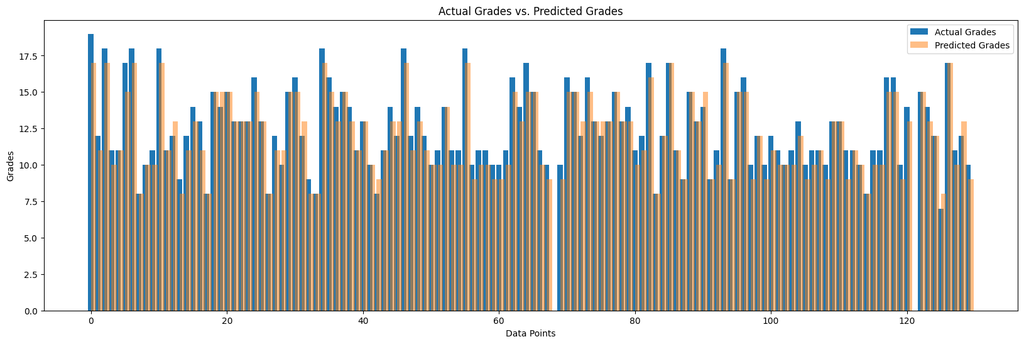

```python
prediction_overview = prediction_overview.sort_values(by="error")

plt.figure(figsize=(20, 6))
plt.bar(prediction_overview.index, prediction_overview["truth"], label="Actual Grades", width=0.8)
plt.bar(prediction_overview.index + 0.4, prediction_overview["prediction"], label="Predicted Grades", width=0.8,alpha=0.5)
plt.xlabel("Data Points")
plt.ylabel("Grades")
plt.title("Actual Grades vs. Predicted Grades")
plt.legend()
plt.show()
```

I decided to visualise the relation between the true grade and the predicted one. As we can see the dots are close to the line, which means that our model is accurate. It appears that the model does fairly well for the higher graded students.

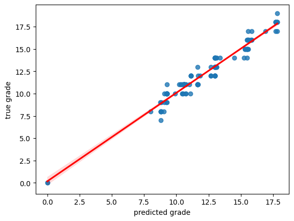

```python
plot = sns.regplot(y=y_test.values.flatten(), x=final_predictions.flatten(), line_kws={"color": "r"})
plot.set_xlabel("predicted grade")
plot.set_ylabel("true grade")
plot
```

In order to get a meaningful indication of the errors that my model makes, I am now going to calculating the maximum error and the root of the mean squared error. A lower Mean squeared error predicts that model's predictions are close to the actual values.

```python
me = max_error(y_test, final_predictions)
me = math.ceil(me)
print("Max Error:", me)

mse = mean_squared_error(y_test, ensemble_preds)
rmse = math.sqrt(mse)
rmse = math.ceil(rmse)
print("Root Mean Squared Error:", rmse)
```

```
Max Error: 2
Root Mean Squared Error: 2
```

# Different models

## Decision tree

In this part, we will look at how to utilize a Decision Tree model for prediction. We assess the correctness of the model, although Linear Regression is recommended over Decision Trees due to its better alignment with dataset characteristics and higher accuracy.

```
Accuracy: 0.48
```

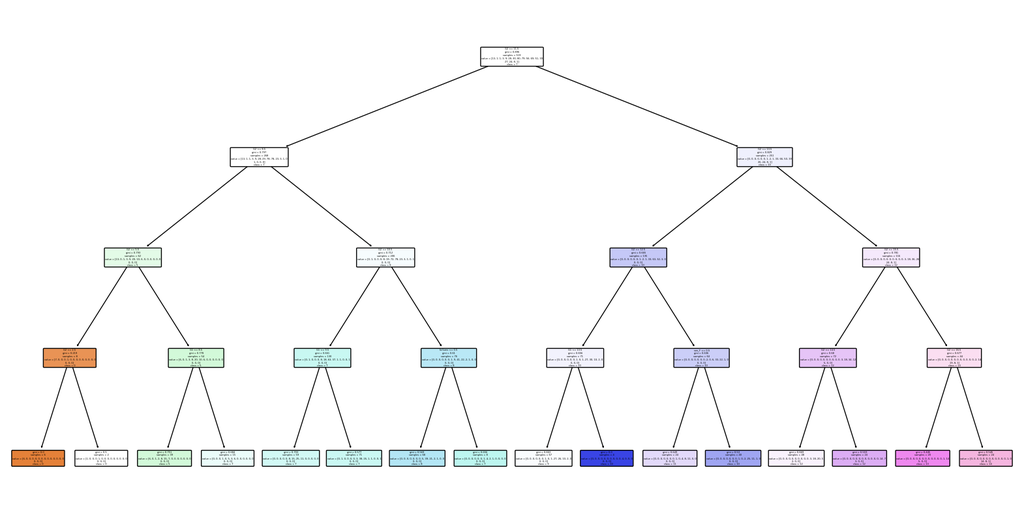

```python
model = DecisionTreeClassifier(max_depth=4)
model.fit(X_train, y_train)
y_pred = model.predict(X_test)

accuracy = accuracy_score(y_test, y_pred)
print(f"Accuracy: {accuracy:.2f}")

plt.figure(figsize=(20, 10))
plot_tree(model, feature_names=features, class_names=[str(i) for i in range(0, 21)], filled=True, rounded=True)
plt.show()
```

# K-means model

Finally, a K-Means model is taken into account. The elbow approach is used to calculate the ideal number of clusters. Clustering, on the other hand, is not the optimal strategy for this purpose because it is normally used to group data points based on similarities rather than forecasting final scores.

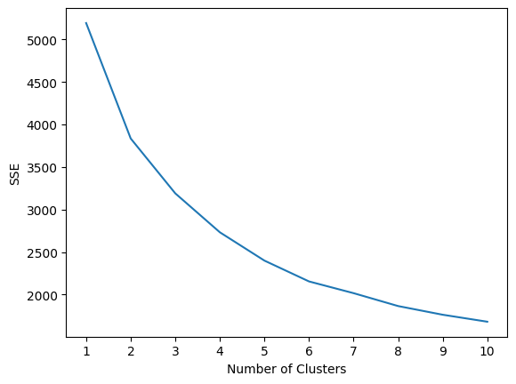

```python
from sklearn.preprocessing import StandardScaler
from sklearn.cluster import KMeans
X = df[features]
scaler = StandardScaler()
scaled_data = scaler.fit_transform(X)

sse=[]
for k in range(1,11):
    kmeans=KMeans(n_clusters=k)
    kmeans.fit(scaled_data)
    sse.append(kmeans.inertia_)

plt.plot(range(1, 11), sse)
plt.xticks(range(1, 11))
plt.xlabel("Number of Clusters")
plt.ylabel("SSE")
plt.show()
```

Based on the plot, the number of clusters is around 3.

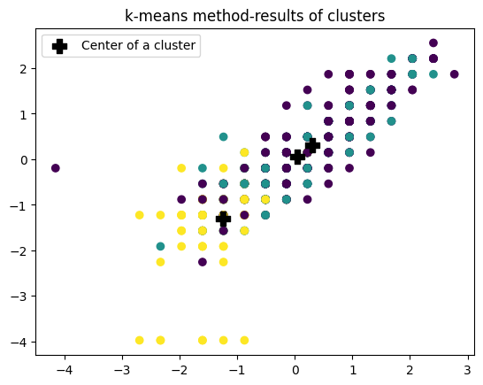

```python
kmeans=KMeans(n_clusters=3,random_state=0)
kmeans.fit(scaled_data)
centroids=kmeans.cluster_centers_
u_labels=kmeans.labels_
plt.scatter(scaled_data[:, 0],scaled_data[:,1],c=kmeans.labels_,cmap='viridis')
plt.scatter(centroids[:,0],centroids[:,1],marker='P',label="Center of a cluster",s=120,c="black")
plt.legend()
plt.title('k-means method-results of clusters')
plt.show()
```

Clustering in my case is not the best method, since typically clustering is used for grouping data points into different groups based on similarities and not to make predictions about final grade.

## Evaluation

In conclusion, I believe my notebook provides a thorough and methodical investigation of a machine learning project, resulting in an accuracy rate of around 90%. The analysis's strategic feature selection, which gave careful thought to aspects that directly affected the project's outcome, is what makes it strong. The achievement of such great precision was probably made possible by this focused strategy. The robustness of the study is enhanced by the inclusion of a variety of regression models, such as Random Forest, KNN, SVR, and Linear Regression, which provide a careful investigation of algorithmic diversity. The results have an additional degree of dependability because the model performance is assessed using cross-validation. I believe that using this notebook in some educational instutions is going to help teachers and students to work better and achieve better results.

### Demonstration and feedback

I consistently engaged stakeholders in biweekly demos to foster an iterative and collaborative development approach throughout the project. During these crucial demonstrations, I presented the machine learning notebook's development process. Through the whole process, I made sure my stakeholder was kept informed about the project's progress. Their insightful criticism, which I received throughout these meetings, was really helpful to me in honing my concepts and coming to wise conclusions. In addition to improving the analysis's overall quality, this iterative feedback loop promoted teamwork and a sense of shared project ownership. I increased the project's capabilities by adding a user-friendly React front end to go along with the backend machine learning analysis. This frontend not only makes the project more accessible, but it also makes it easier for stakeholders who might not be very technical to engage with one another. Additionally, I used Flask as the backend API to make it simple to install and retrieve the machine learning models. This tactical choice allows the integration of the machine learning models into several applications or platforms in addition to guaranteeing a stable and scalable architecture. At the end, I showed my project to my stakeholder and to other people who are currently studying and based on the feedback, I did some small updates. Overall, people who tried the application were satisfied with what I managed to present.